# Projekt Metody Statystyczne - Dokumentacja

Autorzy: Mateusz Adamczyk, Natalia Cheba, Tomasz Depczyński, Julia Kwapień, Anna Szkoda, Maciej Zajęcki

Data sprawozdania: 07-06-2020

## Przygotowanie danych do dalszej analizy

##### - Zamiana nazwy kolumn na odpowiednie nazwy

```r
library(tidyr)
names(Autko)[1] <- "mpg"
names(Autko)[2] <- "cylinders"
names(Autko)[3] <- "displacement"
names(Autko)[4] <- "horsepower"
names(Autko)[5] <- "weight"
names(Autko)[6] <- "acceleration"
names(Autko)[7] <- "model_year"
names(Autko)[8] <- "origin"
names(Autko)[9] <- "car_name"
```

##### - Zmienienie na odpowiednie typy danych

```r
Autko$car_name<-as.character(Autko$car_name)
Autko$cylinders = Autko$cylinders %>% factor(labels = sort(unique(Autko$cylinders)))
Autko$model_year = Autko$model_year %>% factor(labels = sort(unique(Autko$model_year)))
Autko$origin = Autko$origin %>% factor(labels = sort(unique(Autko$origin)))
Autko$horsepower<-as.numeric(Autko$horsepower)
```

##### - Oddzielenie marki i modelu

```r
Autko <- separate(Autko, col = c("car_name"), into = c("brand", "model"), sep = " ", extra = "merge")
```

##### - Zamiana “?” na wartosci N/A

```r
Autko[Autko == "?"] <- NA
```

##### - Zastępowanie wartości NULL średnią

```r
Autko$horsepower <- ifelse(is.na(Autko$horsepower), mean(Autko$horsepower, na.rm=TRUE), Autko$horsepower)
```

##### - Zamiana brandów na odpowiednie nazwy

```r
Autko$brand[Autko$brand == "chevroelt"] <- "chevrolet"
Autko$brand[Autko$brand == "maxda"] <- "mazda"
Autko$brand[Autko$brand == "vokswagen"] <- "volkswagen"
Autko$brand[Autko$brand == "toyouta"] <- "toyota"
Autko$brand[Autko$brand == "vw"] <- "volkswagen"
Autko$brand[Autko$brand == "mercedes-benz"] <- "mercedes"
```

##### - Zamiana na factory

```r
Autko$brand = Autko$brand %>%
  factor(labels = sort(unique(Autko$brand)))
```

## Statystyka

##### - Aby wyliczyć wszystkie miary statystyczne została utworzona funkcja:

```r
library(knitr)
library(e1071)
funkcja_pomiary_statystyczne <- function(wektor){
  srednia_arytm <- mean(wektor)
  mediana <- median(wektor)
  dominanta <- funkcja_dominanta(wektor)
  kwartyl1 <- as.numeric(quantile(wektor, probs = 0.25))
  kwartyl3 <- as.numeric(quantile(wektor, probs = 0.75))
  wariancja <- var(wektor)
  wariancja_Obc <- wariancja * (length(wektor) - 1)/length(wektor)
  odchyl_stand <- sqrt(wariancja)
  odchyl_stand_Obc <- sqrt (wariancja_Obc)
  odchyl_przec <- sum(abs(wektor - srednia_arytm))/length(wektor)
  odchyl_cwiart <- (kwartyl3 - kwartyl1)/2
  klas_wspol_zmienn <- odchyl_stand/srednia_arytm
  pozyc_wspol_zmienn <- odchyl_cwiart/mediana
  kurtoza <- kurtosis(wektor)
  eksces <- kurtoza - 3
  wsk_asymetrii <- kwartyl3 - (2 * mediana) + kwartyl1
  wspol_asymertii <- wsk_asymetrii / (2 * odchyl_cwiart)
  dol_typ_obsz_zmienn <- srednia_arytm - odchyl_stand
  gor_typ_obsz_zmienn <- srednia_arytm + odchyl_stand

  rezultat <- c(srednia_arytm, mediana, dominanta, kwartyl1, kwartyl3, wariancja,
                wariancja_Obc, odchyl_stand, odchyl_stand_Obc, odchyl_przec,
                odchyl_cwiart, klas_wspol_zmienn, pozyc_wspol_zmienn, kurtoza,
                eksces, wsk_asymetrii, wspol_asymertii, dol_typ_obsz_zmienn,
                gor_typ_obsz_zmienn)

  return(rezultat)
}
```

##### - Do obliczenia dominanty należało napisać dodatkową funkcję:

```r
funkcja_dominanta <- function(x) {
  ux <- unique(x)
  ux[which.max(tabulate(match(x, ux)))]
}
```

##### - Wszystkie dane zostały zaokrąglone do 4 miejsca po przecinku:

```r
mpg_ <- round( funkcja_pomiary_statystyczne(Autko$mpg), digits = 4)
acceleration_ <- round(funkcja_pomiary_statystyczne(Autko$acceleration), digits = 4)
displacement_ <- round(funkcja_pomiary_statystyczne(Autko$displacement), digits = 4)
horsepower_ <-  round(funkcja_pomiary_statystyczne(Autko$horsepower), digits = 4)
weight_ <- round(funkcja_pomiary_statystyczne(Autko$weight), digits = 4)
```

##### - Oraz zapisane w formacie date frame:

```r
tmp <- data.frame(mpg_, acceleration_,displacement_, horsepower_, weight_)
```

##### - Zostały również nazwane wszystkie wiersze tabeli:

```r
row.names(tmp) <- c("srednia arytmetyczna: ", "mediana: ", "dominanta: ", "kwartyl 0.25: ", "kwartyl 0.75: ",
                    "wariancja: ", "wariancja obciazona: ", "odchylenie standardowe: ",
                    "odchylenie standardowe obciazone: ", "odchylenie przecietne: ",
                    "odchylenie cwiartkowe: ", "klasyczny wspolczynnik zmiennosci: ",
                    "pozycyjny wspolczynnik zmiennosci: ", "kurtoza: ", "eksces: ",
                    "wskaznik asymetrii: ", "wspolczynnik asymetrii: ",
                    "dolna granica typowego obszaru zmiennosci: ",
                    "gorna granica typowego obszaru zmiennosci: ")
```

I tak obliczone i zapisane pomiary możemy wypisać:

```r
print(tmp)
```

```
##                                                mpg_ acceleration_ displacement_
## srednia arytmetyczna:                       23.5146       15.5681      193.4259
## mediana:                                    23.0000       15.5000      148.5000
## dominanta:                                  13.0000       14.5000       97.0000
## kwartyl 0.25:                               17.5000       13.8250      104.2500
## kwartyl 0.75:                               29.0000       17.1750      262.0000
## wariancja:                                  61.0896        7.6048    10872.1992
## wariancja obciazona:                        60.9361        7.5857    10844.8821
## odchylenie standardowe:                      7.8160        2.7577      104.2698
## odchylenie standardowe obciazone:            7.8062        2.7542      104.1388
## odchylenie przecietne:                       6.5334        2.1426       91.3526
## odchylenie cwiartkowe:                       5.7500        1.6750       78.8750
## klasyczny wspolczynnik zmiennosci:           0.3324        0.1771        0.5391
## pozycyjny wspolczynnik zmiennosci:           0.2500        0.1081        0.5311
## kurtoza:                                    -0.5319        0.3821       -0.7636
## eksces:                                     -3.5319       -2.6179       -3.7636
## wskaznik asymetrii:                          0.5000        0.0000       69.2500
## wspolczynnik asymetrii:                      0.0435        0.0000        0.4390
## dolna granica typowego obszaru zmiennosci:  15.6986       12.8104       89.1560
## gorna granica typowego obszaru zmiennosci:  31.3306       18.3258      297.6957
##                                             horsepower_     weight_
## srednia arytmetyczna:                          104.4694   2970.4246
## mediana:                                        95.0000   2803.5000
## dominanta:                                     150.0000   2130.0000
## kwartyl 0.25:                                   76.0000   2223.7500
## kwartyl 0.75:                                  125.0000   3608.0000
## wariancja:                                    1459.1779 717140.9905
## wariancja obciazona:                          1455.5116 715339.1287
## odchylenie standardowe:                         38.1992    846.8418
## odchylenie standardowe obciazone:               38.1512    845.7772
## odchylenie przecietne:                          29.9022    717.9216
## odchylenie cwiartkowe:                          24.5000    692.1250
## klasyczny wspolczynnik zmiennosci:               0.3656      0.2851
## pozycyjny wspolczynnik zmiennosci:               0.2579      0.2469
## kurtoza:                                         0.7103     -0.8018
## eksces:                                         -2.2897     -3.8018
## wskaznik asymetrii:                             11.0000    224.7500
## wspolczynnik asymetrii:                          0.2245      0.1624
## dolna granica typowego obszaru zmiennosci:      66.2702   2123.5828
## gorna granica typowego obszaru zmiennosci:     142.6686   3817.2664
```

Po wyliczeniu miar charakteryzujących rozkład, dokonano ich analizy dla wybranych cech ilościowych wybranej bazy:

### MPG (miles per gallons)

Typowe wartości cechy mpg znajdują się w zakresie od 15,7 do 31,33. W tym zakresie mieści się średnia arytmetyczna oraz mediana. Miara odchylenia standardowego wynosi około 1/3 wartości średniej, dlatego możemy przyjąć, że wyliczona średnia jest w miarę trafną wartością dla danych. Klasyczny współczynnik zmienności, czyli procent odchylenia standardowego w średniej arytmetycznej, wynosi 33% i oznacza, że wyniki nie są odchylone w bardzo dużym stopniu od średniej. Na podstawie wskaźnika i współczynnika asymetrii, możemy wnioskować, że asymetria wyników jest prawostronna i jest niewielka. Na prawostronną asymetrię również wskazuje mniejsza wartość dominanty w stosunku do średniej arytmetycznej. Wyliczony eksces określa nam poziom koncentracji wokół średniej, który jest niższy niż w rozkładzie normalnym.

### ACCELERATION

Przyspieszanie (acceleration) przyjmuje typowe wartości w zakresie od 12,81 do 18,33. Mediana oraz średnia arytmetyczna zawierają się w tym przedziale i mają bardzo zbliżone do siebie wartości. Klasyczny współczynnik zmienności wynosi w przybliżeniu 18% i informuje nas o bardzo małej zmienności wartości wokół średniej. Wskaźnik oraz współczynnik asymetrii są równe 0, więc występuje tutaj symetria wyników. Eksces przyjmuje wartość ujemną, więc poziom koncentracji wyników wokół średniej jest niższy niż w rozkładzie normalnym.

### DISPLACEMENT

Typowe wartości cechy displacement znajdują się w zakresie od 89,16 do 297,70. W tym przedziale zawierają się średnia arytmetyczna oraz mediana. Klasyczny współczynnik zmienności wynosi 53,91% co wskazuje na dużą zmienność wartości w okolicy średniej arytmetycznej. Wskaźnik asymetrii ma wartość dodatnią, dlatego możemy stwierdzić, że asymetria jest prawostronna. Współczynnik określa, że jest to duża asymetria. Dominanta również w tym przypadku jest mniejsza od średniej arytmetycznej co utwierdza nas w prawostronnej asymetrii. Obliczony poziom koncentracji wokół średniej w stosunku do poziomu koncentracji w rozkładzie normalnym jest o wiele niższy.

### HORSEPOWER

Cecha horsepower przyjmuje typowe wartości w przedziale od 66,27 do 142,67. W tym przedziale znajdują się średnia arytmetyczna i mediana. Klasyczny współczynnik zmienności wynosi około 37%. Wskazuje to na małą zmienność wartości cechy dookoła średniej. Wskaźnik asymetrii wskazuje na występowanie asymmetrii prawostronnej. Jest to jednak mała asymetria o czym informuje nas współczynnik asymetrii. Poziom koncentracji wokół średniej jest niższy w porównaniu z koncentracją w rozkładzie normalnym.

### WEIGHT

Typowe wartości określające wagę samochodów (weight) mieszczą się w zakresie od 2123,58 do 3817,27. średnia arytmetyczna, mediana oraz dominanta zawierają się w tym przedziale. Klasyczny wspołczynnik zmienności wynosi 28,51%. Oznacza to niewielką zmienność wartości cechy dookoła średniej. Wskaźnik asymetrii jest dodatni, co określa że asymetria jest prawostronna. Niski współcznynnik asymetrii wskazuje, że nie jest to silna asymetria. Wartość dominanty jest mniejsza od średniej co również wskazuje na występowanie prawostronnej asymetrii. Wyliczony eksces jest ujemny. Mówi nam to o niższej koncentracji wartości wokół średniej w porównaniu do koncentracji w rozkładzie normalnym.

## Wykresy słupkowe

Wykres słupkowy jest jedną z graficznych możliwości przedstawiania i prezentacji danych statystycznych.  
Stosuje się je do ilustracji struktury szeregów strukturalnych, przedziałowych, przestrzennych i czasowych. Wykresy słupkowe mają postać prostokątów (słupków) równoległych do siebie. Każdy z prostokątów przedstawia liczebność danego wariantu cechy.

Tak tworzy się wykres słupkowy:

##### - dla Cylinders,

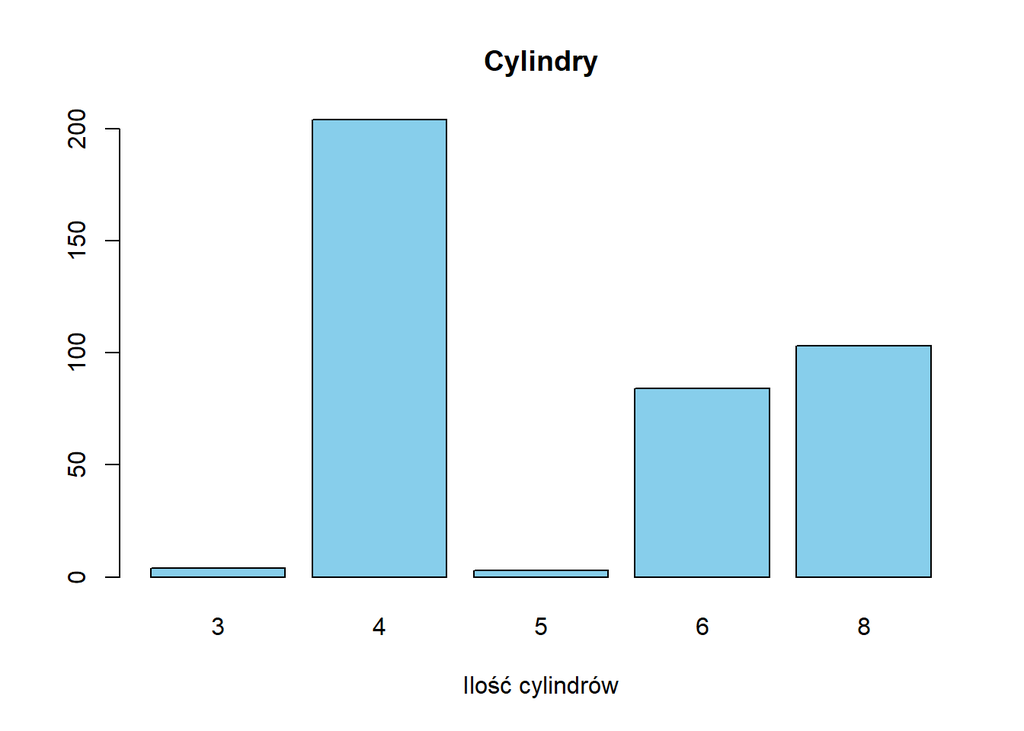

```r
barplot(table(Autko$cylinders), main = "Cylindry", xlab = "Ilość cylindrów", col = "sky blue")
```

Z wykresu wynika, że najwięcej aut ma parzystą liczbę cylindrów. Najwięcej aut jest wyposarzone w 4 cylindry, dwa razy mniej aut posiada 8 bądź 6 cylindrów.

##### - dla Model_year,

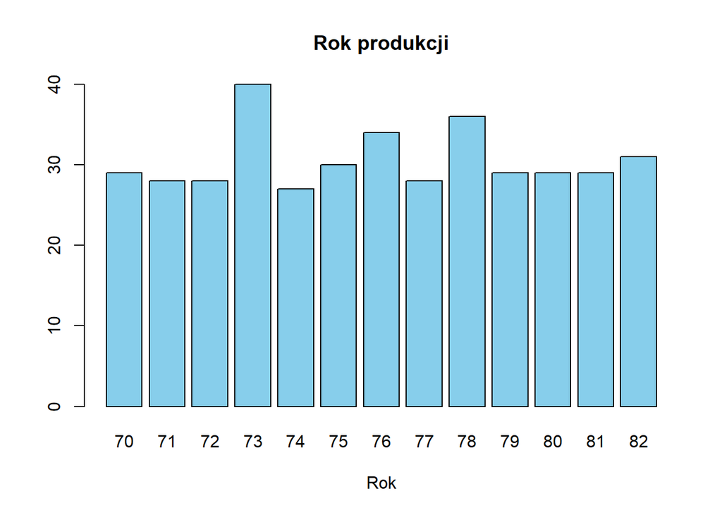

```r
barplot(table(Autko$model_year), main = "Rok produkcji", xlab = "Rok", col = "sky blue")
```

Najwięcej aut pochodzi z rocznika 73., lecz nie jest to wielka różnica w porównaniu do innych lat.

##### - dla Origin,

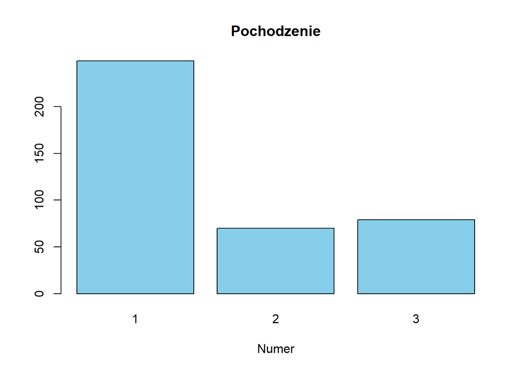

```r
barplot(table(Autko$origin), main = "Pochodzenie", xlab = "Numer", col = "sky blue")
```

Największa liczba aut pochodzi ze Stanów Zjednoczonych (1), auta wyprodukowane w Japoni (3) oraz Europie (2) stanowią mniejszy odsetek.

## Histogramy

Histogram to zestawienie danych statystycznych w postaci wykresu powierzchniowego złożonego z przylegających do siebie słupków, których wysokość ilustruje liczebność występowania badanej cechy w populacji lub jej próbie, a podstawy są rozpiętościami przedziałów klasowych.

Aby uzyskać taki wykres należy:

- ustalić wartości cechy minimalnej i maksymalnej
- obliczyć rozstęp przedziałów klasowych
- obliczyć ilość rekordów
- obliczyć liczbę klas
- obliczyć długość klas (szerokość przedziałów)
- określić wartości dla poszczególnych przedziałów

```r
wynik <- function(x)
{
  min <- min(x, na.rm = TRUE)
  max <- max(x, na.rm = TRUE)
  zakres <- as.numeric(max - min)
  ilosc <- as.numeric(nrow(Autko))
  pierwiastek <- sqrt(ilosc)
  pierwiastek <- ceiling(pierwiastek)
  szer <- zakres / pierwiastek
  szer <-szer[1]
  pkt = seq(min, max, by = szer)
  rezultat <- c(min, max, szer, pkt)
  return(rezultat)
}
```

Teraz możemy zapisać wszystkie dane w wektorze:

```r
mpg<-wynik(Autko$mpg)
dis<-wynik(Autko$displacement)
kg<-wynik(Autko$weight)
pow<-wynik(Autko$horsepower)
acc<-wynik(Autko$acceleration)
```

Następnie określamy przedziały:

```r
przedzialmpg <- cut(Autko$mpg, mpg[-c(1,2,3)], right = FALSE, include.lowest = TRUE)
przedzialdis <- cut(Autko$displacement, dis[-c(1,2,3)], right = FALSE, include.lowest = TRUE)
przedzialpow <- cut(Autko$horsepower, pow[-c(1,2,3)], right = FALSE, include.lowest = TRUE)
przedzialkg <- cut(Autko$weight, kg[-c(1,2,3)], right = FALSE, include.lowest = TRUE)
przedzialacc <- cut(Autko$acceleration, acc[-c(1,2,3)], right = FALSE, include.lowest = TRUE)
```

Na koniec musimy wyznaczyć jeszcze szeregi rozdzielcze:

```r
szeregmpg <- table(przedzialmpg)
szeregdis <- table(przedzialdis)
szeregpow <- table(przedzialpow)
szeregkg <- table(przedzialkg)
szeregacc <- table(przedzialacc)
```

Teraz możemy utworzyć histogram:

##### - dla MPG,

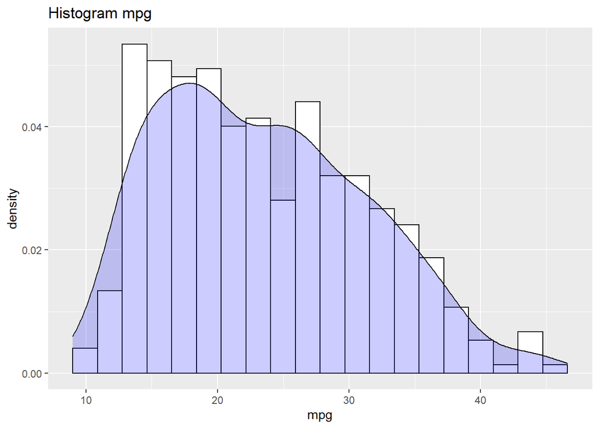

```r
ggplot(Autko, aes(x=mpg)) + geom_histogram(breaks =  mpg[-c(1,2,3)] , aes(y=..density..),  colour="black", fill="white") + geom_density(alpha=.2, fill="blue") + labs(title = "Histogram mpg")
```

Rozkład jest prawostronnie skośny.

##### - dla Displacement,

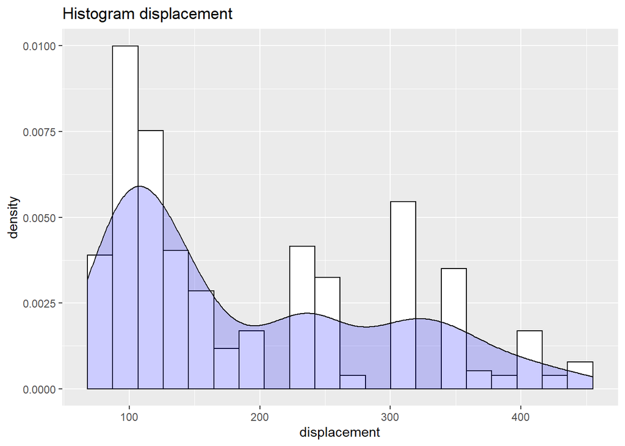

```r
ggplot(Autko, aes(x=displacement)) + geom_histogram(breaks = dis[-c(1,2,3)], aes(y=..density..),  colour="black", fill="white") + geom_density(alpha=.2, fill="blue") + labs(title = "Histogram displacement")
```

Rozkład jest wielomodalny.

##### - dla Horsepower,

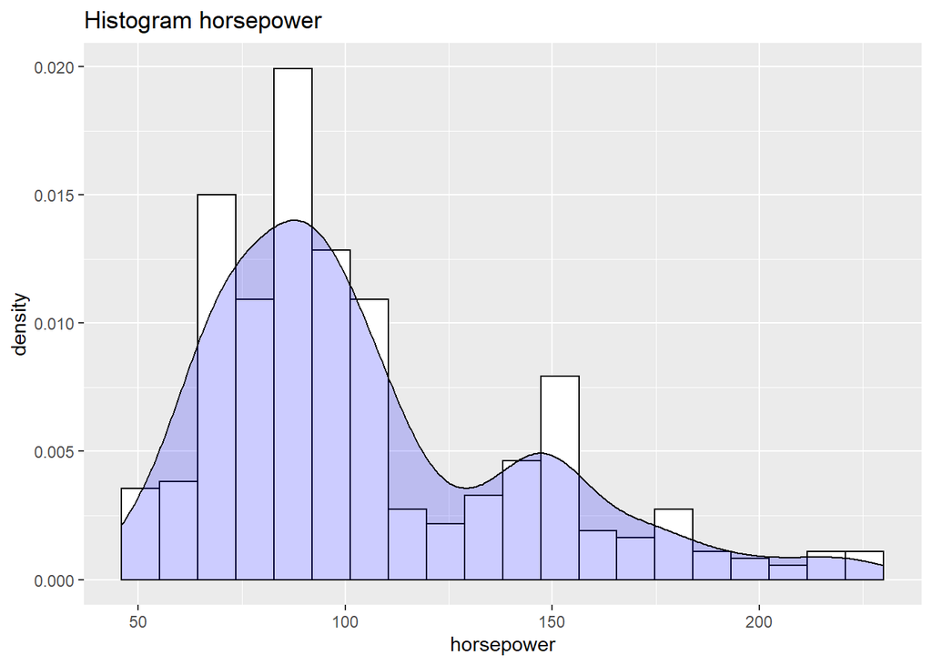

```r
ggplot(Autko, aes(x=horsepower)) +  geom_histogram(breaks = pow[-c(1,2,3)], aes(y=..density..),  colour="black", fill="white") + geom_density(alpha=.2, fill="blue") + labs(title = "Histogram horsepower")
```

Rozkład jest dwumodalny.

##### - dla Weight,

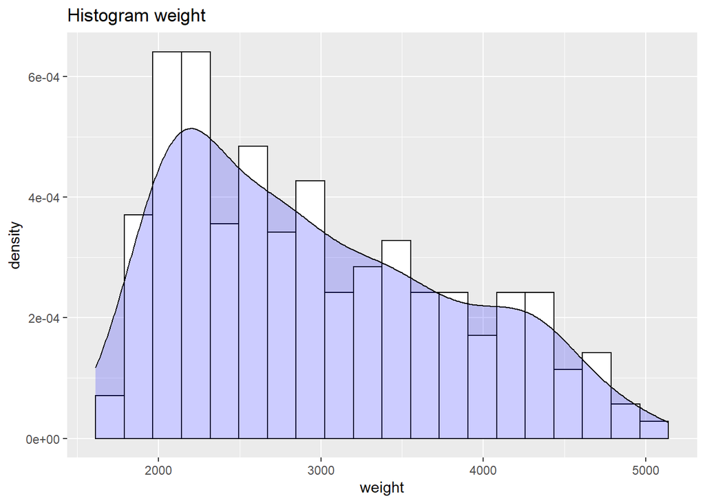

```r
ggplot(Autko, aes(x=weight)) + geom_histogram(breaks = kg[-c(1,2,3)], aes(y=..density..),  colour="black", fill="white") + geom_density(alpha=.2, fill="blue") + labs(title = "Histogram weight")
```

Rozkład jest prawostronnie skośny.

##### - dla Acceleration.

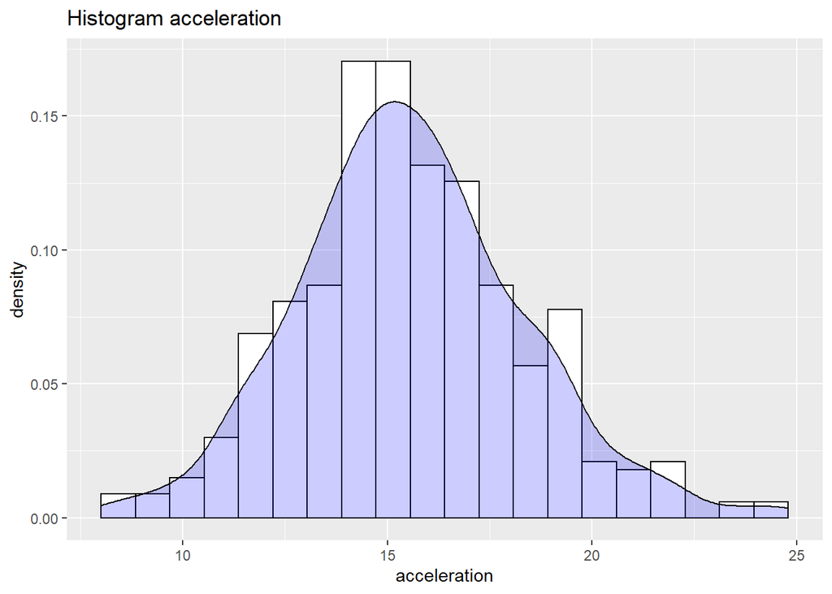

```r
ggplot(Autko, aes(x=acceleration)) + geom_histogram(breaks =acc[-c(1,2,3)]   , aes(y=..density..),  colour="black", fill="white") + geom_density(alpha=.2, fill="blue") + labs(title = "Histogram acceleration")
```

Rozkład jest normalny.

## Boxploty

wykres skrzynkowy niesie ze sobą sporo różnych informacji na temat rozkładu mierzonej zmiennej. Wykres skrzynkowy jest wykresem symetrycznym z punktu widzenia jego poszczególnych elementów. Oczywiście zdarza się, że górny wąs jest dłuższy, a dolny krótszy. Czasami obserwacje odstające są tylko na górze, a czasami tylko na dole. W takim sensie wykres skrzynkowy może być bardzo asymetryczny.

“Podłoga” i “sufit” skrzynki to wartości zamykające skrzynkę z dołu i z góry to wyniki pierwszego kwartyla (Q1) i trzeciego kwartyla (Q3).

Pozioma linia wewnątrz skrzynki prezentuje wartość mediany, czyli drugiego kwartyla.

##### - dla MPG i Model_year

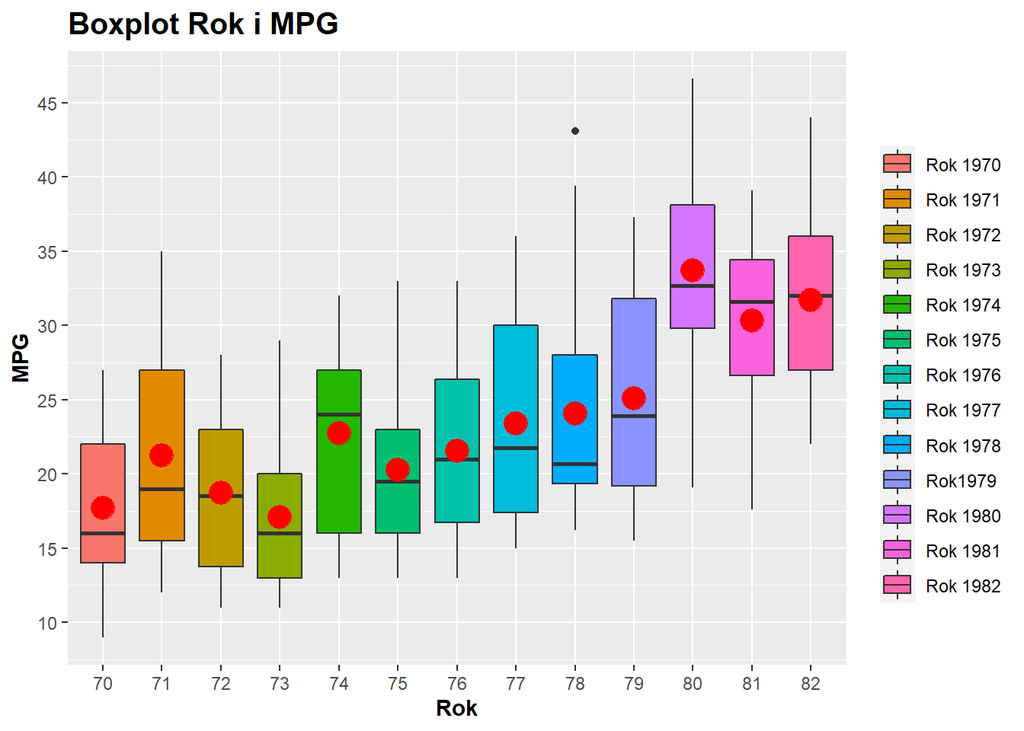

```r
ggplot(Autko,  aes(x=model_year, y=mpg, fill=model_year)) +
  geom_boxplot()  +
  xlab("Rok") + ylab("MPG")+
   theme(axis.title.x = element_text( face="bold"))+
  theme(axis.title.y= element_text( face="bold")) +
  theme(plot.title = element_text(size = 15,  face= 'bold' )) +
  labs(title = "Boxplot Rok i MPG") + scale_y_continuous(breaks =  seq(0,50, by=5)) +
  scale_fill_discrete(name = "", labels = c("Rok 1970", "Rok 1971",  "Rok 1972", "Rok 1973", "Rok 1974",
                                            "Rok 1975", "Rok 1976", "Rok 1977", "Rok 1978", "Rok1979",
                                            "Rok 1980", "Rok 1981", "Rok 1982"))+ stat_summary(fun.y=mean, geom="point", shape=20, size=8, color="red", fill="red")
```

##### - dla Origin i MPG

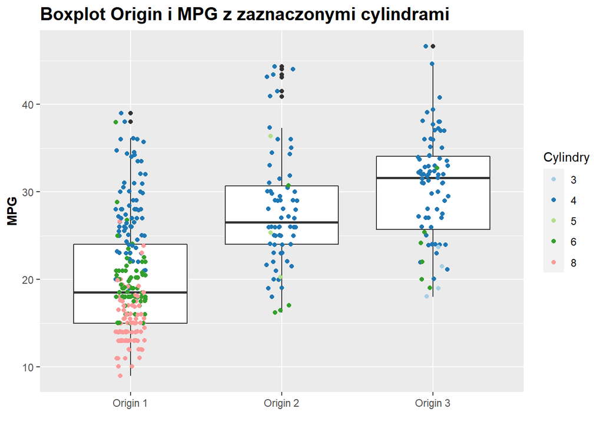

```r
Autko%>%ggplot(aes(x=origin,y=mpg))+geom_boxplot()+geom_jitter(aes(color=cylinders),width = 0.1)+
  scale_x_discrete(labels = c("Origin 1", "Origin 2","Origin 3"))+
  scale_color_brewer(name="Cylindry",type = "qual", palette=3)+scale_fill_manual() +
  xlab("") + ylab("MPG")+
  theme(axis.title.x = element_text( face="bold"))+
  theme(axis.title.y= element_text( face="bold")) +
  theme(plot.title = element_text(size = 15,  face= 'bold' ))+ labs(title = "Boxplot Origin i MPG z zaznaczonymi cylindrami")
```

##### - dla Cylindrów i Wagi

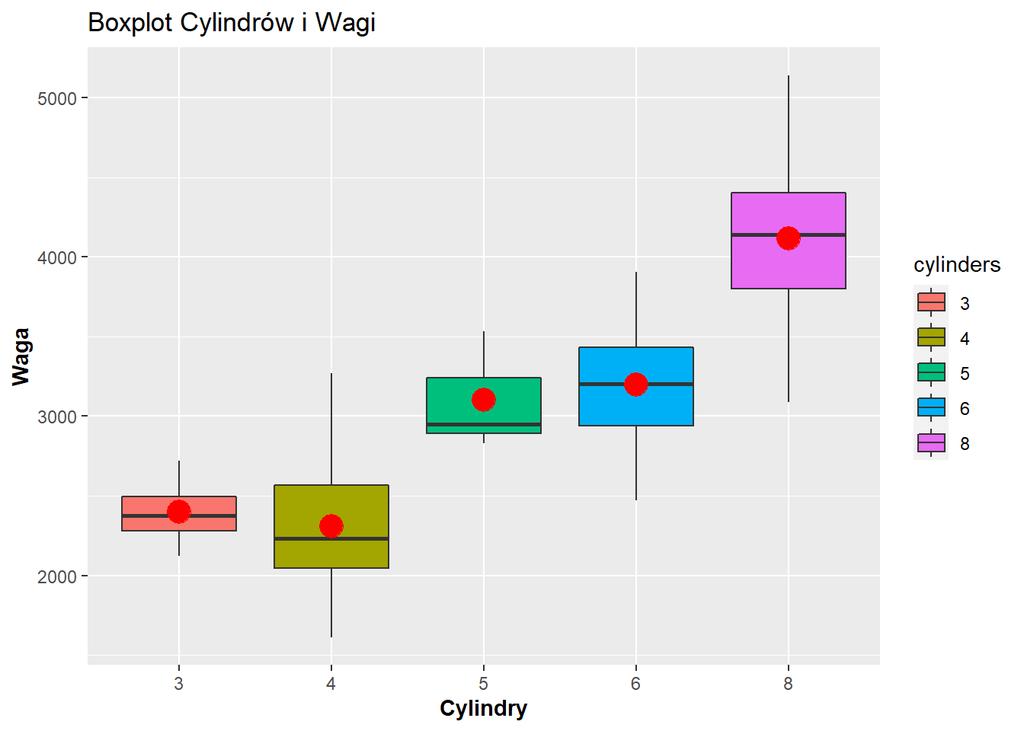

```r
ggplot(Autko, aes(cylinders,weight,fill=cylinders)) +
  geom_boxplot()  +   theme(axis.title.x = element_text( face="bold"))+
  theme(axis.title.y= element_text( face="bold")) +  xlab("Cylindry") +
  ylab("Waga") + labs(title = "Boxplot Cylindrów i Wagi") +
 stat_summary(fun.y=mean, geom="point", shape=20, size=8, color="red", fill="red")
```

##### - dla Origin i Wagi

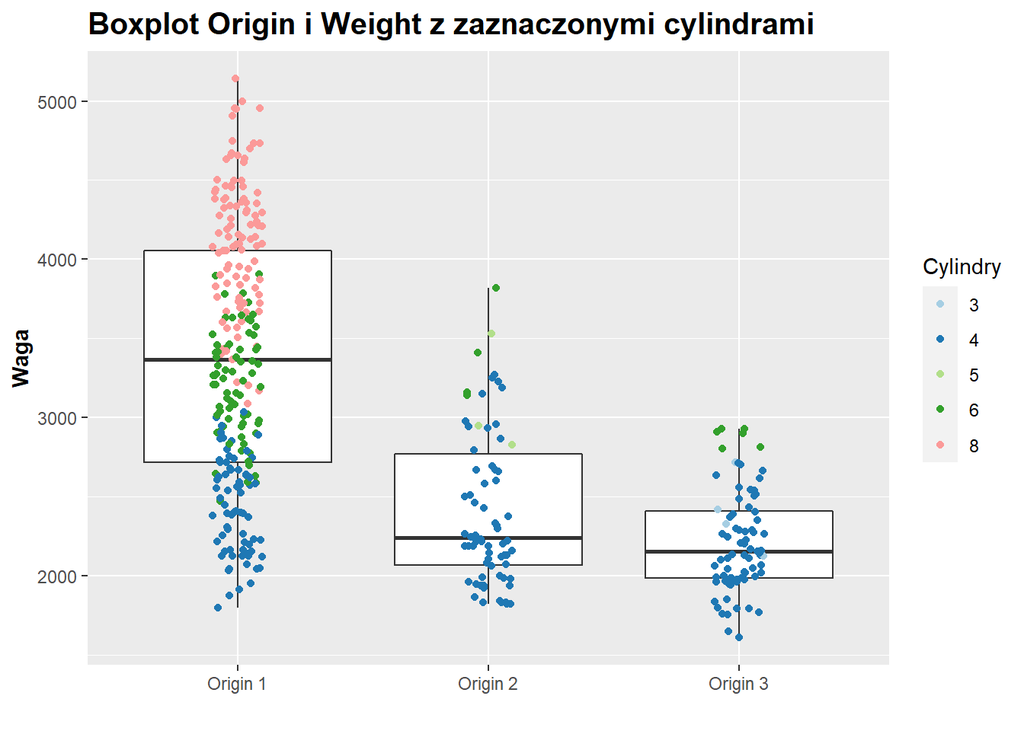

```r
Autko%>%ggplot(aes(x=origin,y=weight))+geom_boxplot()+geom_jitter(aes(color=cylinders),width = 0.1)+
  scale_x_discrete(labels = c("Origin 1", "Origin 2","Origin 3"))+
  scale_color_brewer(name="Cylindry",type = "qual", palette=3)+scale_fill_manual() +
  xlab("") + ylab("Waga")+
  theme(axis.title.x = element_text( face="bold"))+
  theme(axis.title.y= element_text( face="bold")) +
  theme(plot.title = element_text(size = 15,  face= 'bold' ))+ labs(title = "Boxplot Origin i Weight z zaznaczonymi cylindrami")
```

## Cumulative distribution function plot

## Wykres funkcji rozkładu skumulowanego

Procent skumulowany - to statystyczna miara, określająca jaki odsetek “osób”, w tym przypadku samochodów, uzyskał pewien zakres wyników. Jak sama nazwa wskazuje jest to procent złożony z dodawania procentów dla pojedyńczych kategorii - następuje kumulacja.

Dzięki temu w łatwy sposób (bez dodawania) określić odsetek(procent/prawdopodobieństwo) samochodów przyjmujących pewien zakres,  
licząc od początku do danej wartości.

Aby uzyskać taki wykres należy:

- uzyskać dane i obliczyć kluczowe statystyki podsomowujące,
- wyodrębnić wektor danych “mpg” dla Auto-Mpg,

```r
mpg = Autko$mpg
```

- obliczyć liczbę nie brakujących wartości w “mpg”

```r
n = sum(!is.na(mpg));
```

- uzyskać empiryczne wartości CDF

```r
mpg.ecdf = ecdf(mpg)
```

Teraz możemy wykreślić empiryczną funkcję rozkłądu skumulowanego (za pomocą ecdf() i plot()):

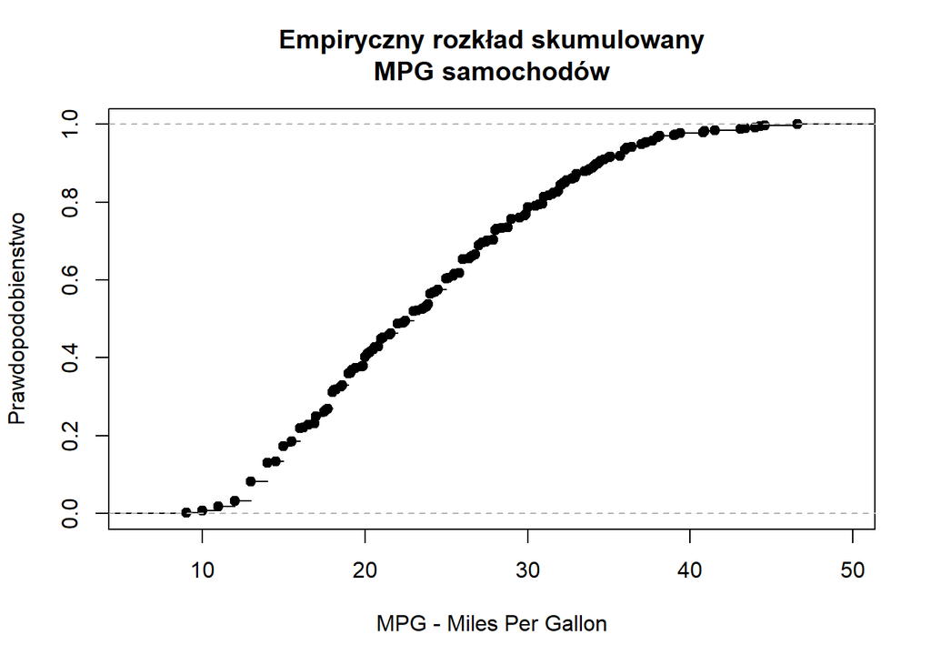

```r
plot(mpg.ecdf, xlab = 'MPG - Miles Per Gallon', ylab = 'Prawdopodobienstwo', main = 'Empiryczny rozkład skumulowany\nMPG samochodów')
```

Dla ostatniej możliwej kategorii/opcji procent zawsze będzie wynosił 100%, gdyż “wyczerpuje” on wszystkie pozostałe kategorie/opcje.

## Wykresy QQ

Aby uzyskać taki wykres należy:

- utworzyć normalny wykres zmiennej -> qqnorm(),
- dodać linię odniesiena -> qqline(),

Teraz możemy utworzyć wykres QQ:

##### - dla MPG,

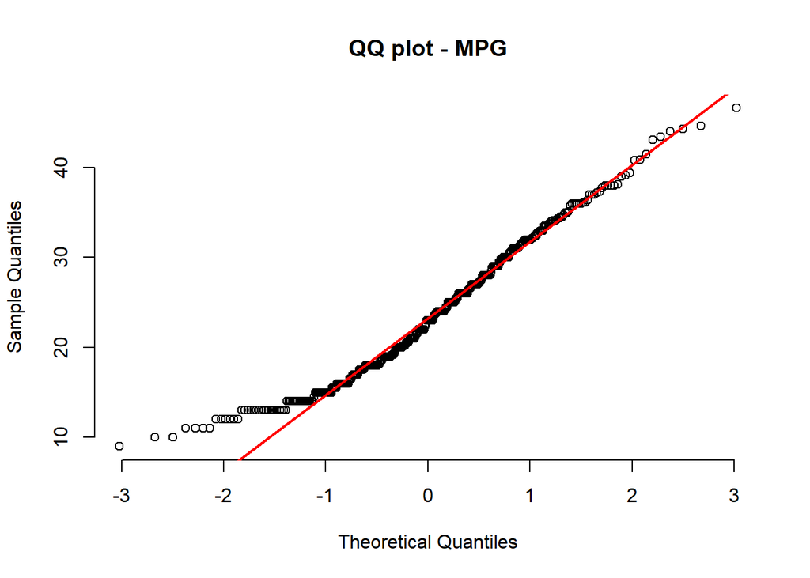

```r
qqnorm(Autko$mpg, pch=1, frame=FALSE, main="QQ plot - MPG")
qqline(Autko$mpg, col='red', lwd=2)
```

##### - dla Displacement,

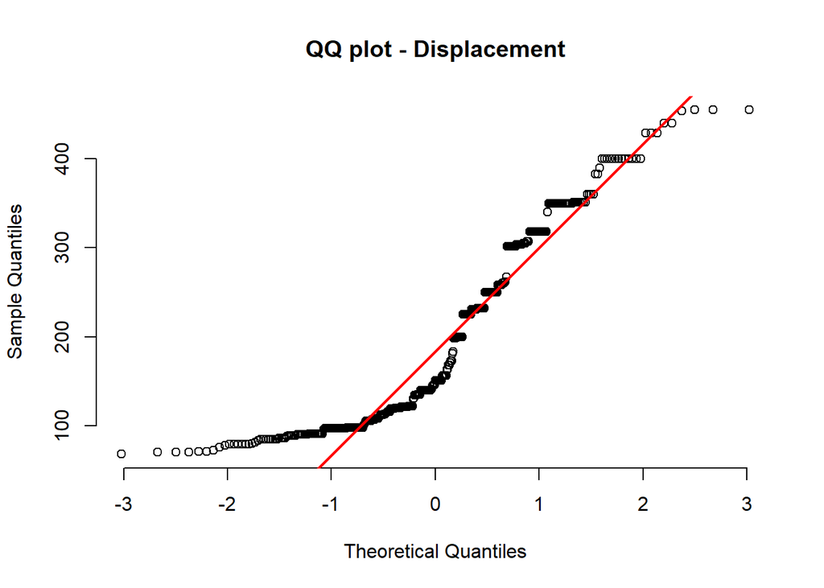

```r
qqnorm(Autko$displacement, pch=1, frame=FALSE, main="QQ plot - Displacement")
qqline(Autko$displacement, col='red', lwd=2)
```

##### - dla Horsepower,

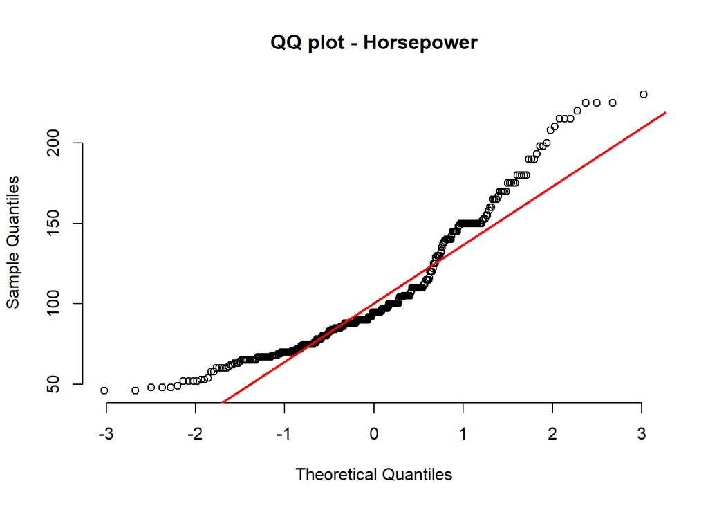

```r
qqnorm(Autko$horsepower, pch=1, frame=FALSE, main="QQ plot - Horsepower")
qqline(Autko$horsepower, col='red', lwd=2)
```

##### - dla Weight,

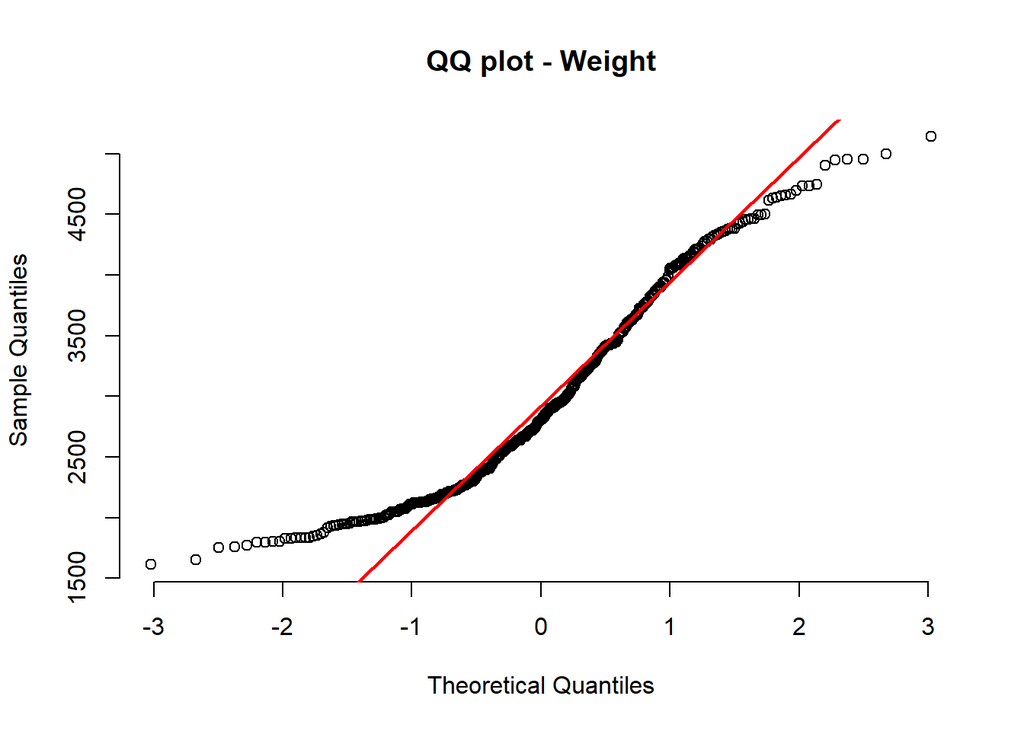

```r
qqnorm(Autko$weight, pch=1, frame=FALSE, main="QQ plot - Weight")
qqline(Autko$weight, col='red', lwd=2)
```

##### - dla Acceleration.

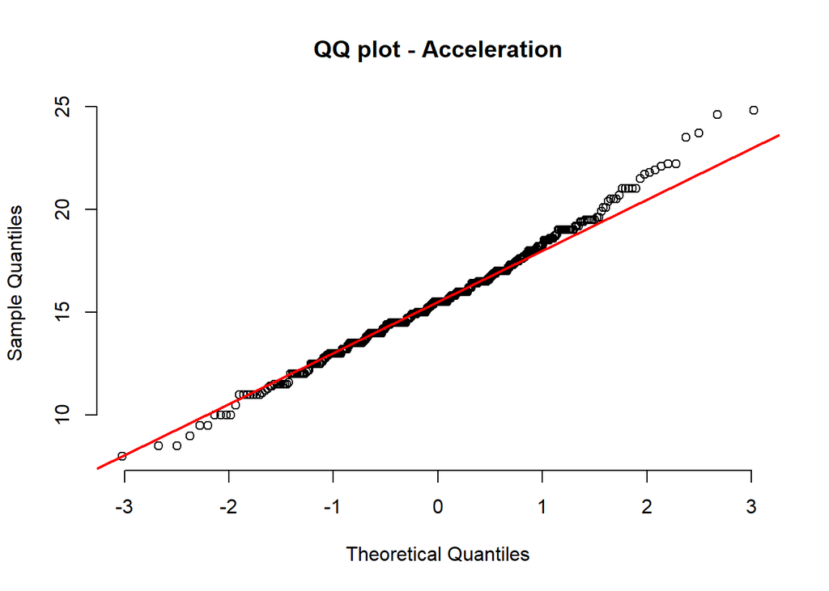

```r
qqnorm(Autko$acceleration, pch=1, frame=FALSE, main="QQ plot - Acceleration")
qqline(Autko$acceleration, col='red', lwd=2)
```

Jeśli wszystkie punkty opadają w przybliżeniu wzdłuż linii odniesienia to możemy założyć normalność.  
Jesli natomiast punkty tworzą krzywą zamiast linię prostą to w tym momencie mamy do czynienia z wypaczeniem danych próbki.

## Scatterplot matrix (by class)

## Wykres macierzy rozrzutu (według klasy)

Macierz rozrzutu umożliwia nam zwizualizowanie korelacji małych zestawów danych. Wykres macierzy rozrzutu pokazuje nam wszystkie pary wykresów rozrzutu zmiennych w jednym widoku w formacie macierzy.

Aby uzyskać wykres macierzy rozrzutu należy:

- utworzyć podstawowy wykres za pomocą -> pairs(),

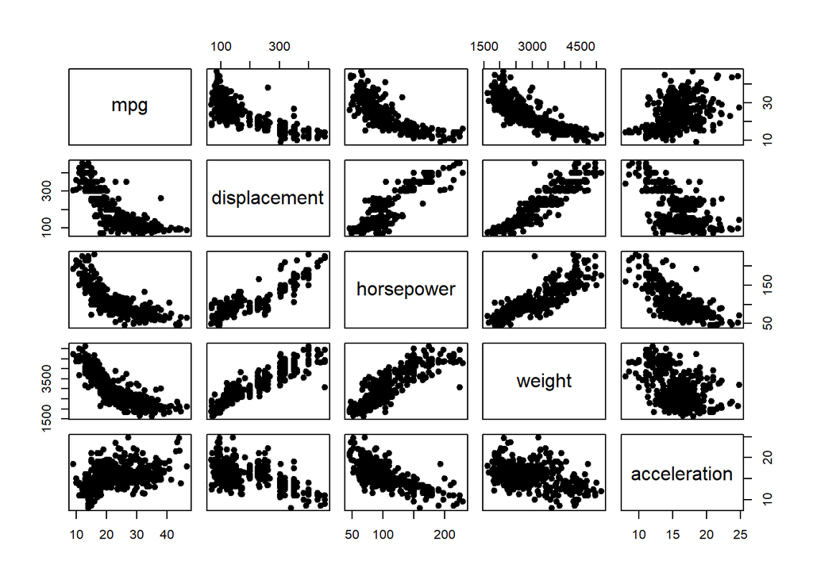

```r
pairs(Autko[c(1,3,4,5,6)], pch = 19)
```

- można usunąć dolną część wykresu,

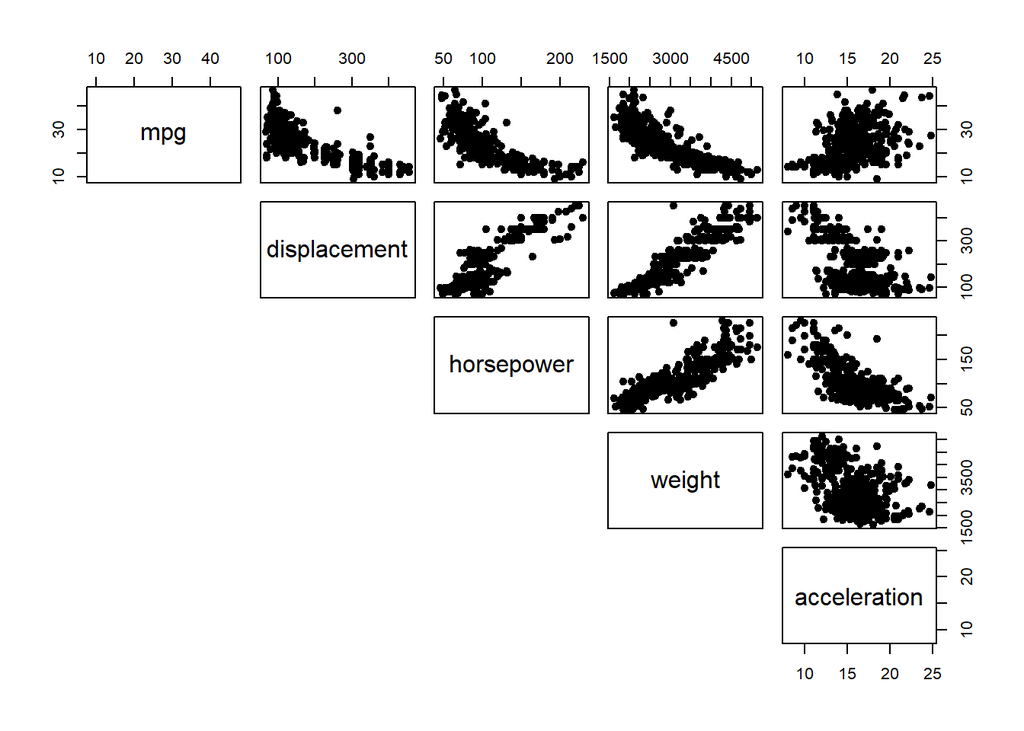

```r
pairs(Autko[c(1,3,4,5,6)], pch = 19, lower.panel=NULL)
```

- można pokolorować punkty poprzez poszczególną klasę (np. origin) w celu lepszego zobrazowania korelacji,

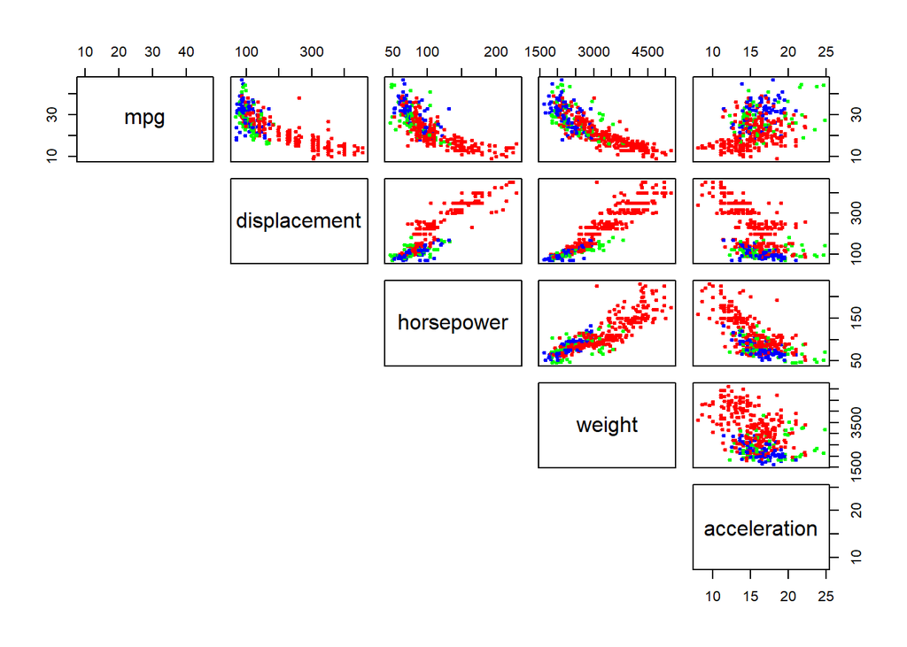

```r
my_cols <- c("#FF0000", "#00FF00", "#0000FF")
pairs(Autko[c(1,3,4,5,6)], pch = 19,  cex = 0.5,
      col = my_cols[Autko$origin],
      lower.panel=NULL)
```

### Utworzenie funkcji do obliczania przedziałów

```r
library(knitr)
library(kableExtra)
przedzialy <- function(x)
{
  srednia = mean(x, na.rm =  TRUE)
  sd <- sd(x, na.rm = TRUE)
  przedz90norm  <- round(srednia+c(-1, 1)*sd/sqrt(398)*qnorm(.95), 2)
  przedz95norm <- round(srednia+c(-1, 1)*sd/sqrt(398)*qnorm(.975), 2)
  przedz99norm <- round(srednia+c(-1, 1)*sd/sqrt(398)*qnorm(.995), 2)
  przedz90war <- round(sqrt(sd*398/qchisq(c(1-.05,.05), 397)), 2)
  przedz95war <- round(sqrt(sd*398/qchisq(c(1-.025,.025), 397)), 2)
  przedz99war <- round(sqrt(sd*398/qchisq(c(1-.005,.005), 397)), 2)
  przedz90t <- round(srednia+c(-1, 1)*sd/sqrt(398)*qt(.95, 397), 2)
  przedz95t <- round(srednia+c(-1, 1)*sd/sqrt(398)*qt(.975, 397), 2)
  przedz99t <- round(srednia+c(-1, 1)*sd/sqrt(398)*qt(.995, 397), 2)

  rezultat <- c(przedz90norm,przedz95norm, przedz99norm,  przedz90war,przedz95war,
                przedz99war, przedz90t, przedz95t, przedz99t)

  return(rezultat)
}
```

### Przypisanie odpowiednim zmiennym rezultatów wykonania funkcji

```r
accp <- przedzialy(Autko$acceleration)
mpgp <- przedzialy(Autko$mpg)
disp <- przedzialy(Autko$displacement)
horsep <- przedzialy(Autko$horsepower)
kgp <- przedzialy(Autko$weight)
```

### Umieszczenie wcześniej utworzonych zmiennych w tabeli

```r
przedzialy <- data.frame(mpgp, accp , disp, horsep, kgp)
```

### Odpowiednie nazwanie tabeli z wyznaczonymi przedziałami

```r
row.names(przedzialy) <- c("początek przedziału dla ufności 90% dla wartości oczekiwanej"  , "koniec  przedziału dla ufności 90% dla wartości oczekiwanej",
                    "początek przedziału dla ufności 95% dla wartości oczekiwanej"  , "koniec  przedziału dla ufności 95% dla wartości oczekiwanej",
                    "początek przedziału dla ufności 99% dla wartości oczekiwanej"  , "koniec  przedziału dla ufności 99% dla wartości oczekiwanej",
                    "początek przedziału dla ufności 90% dla wariancji"  , "koniec  przedziału dla ufności 90% dla wariancji",
                    "początek przedziału dla ufności 95% dla wariancji"  , "koniec  przedziału dla ufności 95% dla wariancji",
                    "początek przedziału dla ufności 99% dla wariancji"  , "koniec  przedziału dla ufności 99% dla wariancji",
                    "początek przedziału dla ufności 90% dla rozkładu t-Gosseta"  , "koniec  przedziału dla ufności 90% dla rozkładu t-Gosseta",
                    "początek przedziału dla ufności 95% dla rozkładu t-Gosseta"  , "koniec  przedziału dla ufności 95% dla rozkładu t-Gosseta",
                    "początek przedziału dla ufności 99% dla rozkładu t-Gosseta"  , "koniec  przedziału dla ufności 99% dla rozkładu t-Gosseta")
colnames(przedzialy) <- c("MPG", "Acceleration", "Displacement",  "Horsepower", "Weight")
```

### Otrzymane przedziały

```r
kable(przedzialy, caption = "Wyznaczone przedziały ufności") %>% kable_styling(bootstrap_options = c("striped", "hover"))
```

Wyznaczone przedziały ufności

|  | MPG | Acceleration | Displacement | Horsepower | Weight |
| --- | --- | --- | --- | --- | --- |
| początek przedziału dla ufności 90% dla wartości oczekiwanej | 22.87 | 15.34 | 184.83 | 101.32 | 2900.60 |
| koniec przedziału dla ufności 90% dla wartości oczekiwanej | 24.16 | 15.80 | 202.02 | 107.62 | 3040.25 |
| początek przedziału dla ufności 95% dla wartości oczekiwanej | 22.75 | 15.30 | 183.18 | 100.72 | 2887.23 |
| koniec przedziału dla ufności 95% dla wartości oczekiwanej | 24.28 | 15.84 | 203.67 | 108.22 | 3053.62 |
| początek przedziału dla ufności 99% dla wartości oczekiwanej | 22.51 | 15.21 | 179.96 | 99.54 | 2861.08 |
| koniec przedziału dla ufności 99% dla wartości oczekiwanej | 24.52 | 15.92 | 206.89 | 109.40 | 3079.76 |
| początek przedziału dla ufności 90% dla wariancji | 2.65 | 1.57 | 9.66 | 5.85 | 27.54 |
| koniec przedziału dla ufności 90% dla wariancji | 2.97 | 1.77 | 10.86 | 6.57 | 30.95 |
| początek przedziału dla ufności 95% dla wariancji | 2.62 | 1.55 | 9.56 | 5.79 | 27.24 |
| koniec przedziału dla ufności 95% dla wariancji | 3.01 | 1.79 | 10.99 | 6.65 | 31.32 |
| początek przedziału dla ufności 99% dla wariancji | 2.56 | 1.52 | 9.36 | 5.67 | 26.68 |
| koniec przedziału dla ufności 99% dla wariancji | 3.08 | 1.83 | 11.25 | 6.81 | 32.05 |
| początek przedziału dla ufności 90% dla rozkładu t-Gosseta | 22.87 | 15.34 | 184.81 | 101.31 | 2900.44 |
| koniec przedziału dla ufności 90% dla rozkładu t-Gosseta | 24.16 | 15.80 | 202.04 | 107.63 | 3040.41 |
| początek przedziału dla ufności 95% dla rozkładu t-Gosseta | 22.74 | 15.30 | 183.15 | 100.71 | 2886.97 |
| koniec przedziału dla ufności 95% dla rozkładu t-Gosseta | 24.28 | 15.84 | 203.70 | 108.23 | 3053.88 |
| początek przedziału dla ufności 99% dla rozkładu t-Gosseta | 22.50 | 15.21 | 179.90 | 99.51 | 2860.56 |
| koniec przedziału dla ufności 99% dla rozkładu t-Gosseta | 24.53 | 15.93 | 206.95 | 109.43 | 3080.29 |

## Sprawdzenie normalności rozkładu danej zmiennej

> W celu sprawdzenia, czy dana zmienna opisana jest rozkładem normalnym (rozkładem Gaussa-Laplace’a) utworzono funkcję korzystającą z testu Shapiro-Wilka. Następnie dla każdej zmiennej dla której istniał sens zweryfikowania rozkładu wykonano tą funkcję.

### Utworzenie funkcji sprawdzającej czy rozkład jest normalny

```r
normalnosc_rozkladu <- function(x)
{
 sh_test <- shapiro.test(x)
 sh_result <- sh_test$p.value
 return(sh_result)
}
```

### Wykonanie funkcji dla zmiennych i zapisanie rezultatów

```r
accn <- normalnosc_rozkladu(Autko$acceleration)
mpgn <- normalnosc_rozkladu(Autko$mpg)
disn <- normalnosc_rozkladu(Autko$displacement)
horsen <- normalnosc_rozkladu(Autko$horsepower)
kgn <- normalnosc_rozkladu(Autko$weight)
```

### Umieszczenie rezultatów w tabeli oraz jej odpowiednie nazwanie

```r
normalnosc <- data.frame(accn, mpgn, disn, horsen, kgn)
row.names(normalnosc) <- c("P-value")
colnames(normalnosc) <- c("Acceleration", "MPG", "Displacement", "Horsepower", "Weight")
```

### Otrzymane wyniki:

```r
kable(normalnosc, caption = "Wyznaczone p-value") %>% kable_styling(bootstrap_options = c("striped", "hover"))
```

Wyznaczone p-value

|  | Acceleration | MPG | Displacement | Horsepower | Weight |
| --- | --- | --- | --- | --- | --- |
| P-value | 0.0398694 | 1e-07 | 0 | 0 | 0 |

> Interpretacja danych z tabeli: P-value wyznaczono w celu oceny, czy dana zmienna opisana jest rozkładem normalnym. Gdy otrzymane p-value jest większe niż 0.05, można przyjąć że zmienna opisana jest rozkładem normalnym. W przypadku naszych danych żadna ze sprawdanych zmiennych nie jest opisana takim rozkładem, jednak najbliżej rozkładu normalnego jest rozkład zmiennej “Acceleration”. Wartości 0 w tabeli oznaczają liczby tak małe, że nie było sensu zapisywania ich w notacji.

## Testowanie hipotez

> Przetestowano różne hipotezy których treści dobrano odpowiednio do naszego zestawu danych. Wszystkie przeprowadzone testy wraz z ich opisem i interpretacją znajdują się poniżej.

### Utworzenie funkcji potrzebnych do przeprowadzenia testów

#### Funkcja do testu dwóch średnich

```r
dwie_srednie <- function(x, y)
{
 ds.test <- t.test(x, y, paired = F)
 ds.p <- ds.test$p.value
 ds.przedzial95 <- round(ds.test$conf.int, 2)
 ds_list <- list("p_value" = ds.p, "przedzial95" = ds.przedzial95)
 return(ds_list)
}
```

### Czy auta ważące więcej niż 3000 funtów przyspieszają inaczej niż auta lżejsze?

##### H0: Samochody ważące więcej niż 3000 funtów mają średnie przyspieszenie takie jak auta lżejsze

##### H1: Samochody ważące więcej niż 3000 funtów średnio przyspieszają wolniej/szybciej niż auta lżejsze

#### Przeprowadzenie testu dwóch średnich

```r
accel_3000 <- dwie_srednie(Autko$acceleration[Autko$weight > 3000], Autko$acceleration[Autko$weight <= 3000])
```

#### Wyświetlenie wyników

```r
accel_3000$p_value
```

```
## [1] 2.217716e-07
```

```r
accel_3000$przedzial95
```

```
## [1] -2.06 -0.95
## attr(,"conf.level")
## [1] 0.95
```

> Interpretacja wyniku: Otrzymany przedział to [-2.06 -0.95] zatem odrzucamy hipotezę zerową i przyjmujemy alternatywną, czyli auta ważące ponad 3000 funtów średnio przyspieszają gorzej niż lżejsze samochody. Różnica w przyspieszeniu jest w przedziale [0.95 2.06].

### Czy auta o pojemności większej niż 250 mają inną moc niż auta z mniejszymi silnikami?

##### H0: Samochody o pojemności większej niż 250 mają średnią moc równą mocy aut o niższej pojemności

##### H1: Samochody o pojemności większej niż 250 mają średnią moc większą/mniejszą niż auta o niższej pojemności

#### Przeprowadzenie testu dwóch średnich

```r
horsepower_disp250 <- dwie_srednie(Autko$horsepower[Autko$displacement > 250], Autko$horsepower[Autko$displacement <= 250])
```

#### Wyświetlenie wyników

```r
horsepower_disp250$p_value
```

```
## [1] 3.184237e-48
```

```r
horsepower_disp250$przedzial95
```

```
## [1] 63.99 76.20
## attr(,"conf.level")
## [1] 0.95
```

> Interpretacja wyniku: Otrzymano przedział [63.99 76.20], czyli hipoteza zerowa zostaje odrzucona. Samochody o pojemności większej niż 250 średnio mają wyższą moc niż auta z mniejszą pojemnością silnika.

### Czy auta ośmiocylindrowe spalają inne ilości paliwa w stosunku do aut sześciocylindrowych?

##### H0: Samochody z silnikami ośmiocylindrowym średnio spalają tyle samo paliwa co auta sześciocylindrowe

##### H1: Samochody z silnikami ośmiocylindrowymi spalają średnio więcej/mniej paliwa w stosunku do sześciocylindrowych

#### Przeprowadzenie testu dwóch średnich

```r
mpg_8cyl_6cyl <- dwie_srednie(Autko$mpg[Autko$cylinders == 8], Autko$mpg[Autko$cylinders == 6])
```

#### Wyświetlenie wyników

```r
mpg_8cyl_6cyl$p_value
```

```
## [1] 1.918243e-18
```

```r
mpg_8cyl_6cyl$przedzial95
```

```
## [1] -6.01 -4.03
## attr(,"conf.level")
## [1] 0.95
```

> Interpretacja wyniku: Przedział wynikowy to [-6.01 -4.03] - odrzucamy hipotezę zerową. Średnie MPG dla samochodów ośmiocylindrowych jest mniejsze (różnica w przedziale [4.03 6.01]), czyli ich spalanie jest większe niż samochodów sześciocylindrowych.

### Czy przyspieszenie aut amerykańskich jest inne niż przyspieszenie aut japońskich?

##### H0: Samochody amerykańskie i japońskie średnio przyspieszają tak samo

##### H1: Samochody amerykańskie średnio przyspieszają lepiej/gorzej niż samochody japońskie

#### Przeprowadzenie testu dwóch średnich

```r
accel_am_jap <- dwie_srednie(Autko$acceleration[Autko$origin == 1], Autko$acceleration[Autko$origin == 3])
```

#### Wyświetlenie wyników

```r
accel_am_jap$p_value
```

```
## [1] 7.362848e-05
```

```r
accel_am_jap$przedzial95
```

```
## [1] -1.69 -0.58
## attr(,"conf.level")
## [1] 0.95
```

> Interpretacja wyniku: Hipoteza zerowa zostaje odrzucona. Otrzymany przedział mówi, że średnio samochody amerykańskie przyspieszają gorzej niż japońskie, a różnica jest w przedziale [0.58 1.69].

### Czy przyspieszenie aut amerykańskich jest inne niż przyspieszenie aut europejskich?

##### H0: Samochody amerykańskie i europejskie średnio przyspieszają tak samo

##### H1: Samochody amerykańskie średnio przyspieszają lepiej/gorzej niż samochody europejskie

#### Przeprowadzenie testu dwóch średnich

```r
accel_am_eu <- dwie_srednie(Autko$acceleration[Autko$origin == 1], Autko$acceleration[Autko$origin == 2])
```

#### Wyświetlenie wyników

```r
accel_am_eu$p_value
```

```
## [1] 3.289438e-05
```

```r
accel_am_eu$przedzial95
```

```
## [1] -2.55 -0.95
## attr(,"conf.level")
## [1] 0.95
```

> Interpretacja wyniku: Odrzucamy hipotezę zerową. Przedział [-2.55 -0.95] mówi, że auta amerykańskie mają gorsze średnie przyspieszenie niż europejskie. Przewaga europejskich jest w przedziale [0.95 2.55].

#### Przeprowadzenie testu ANOVA

```r
accelerationOriModel.0 <- lm(acceleration~1, data = Autko)
accelerationOriModel.1 <- lm(acceleration~origin, data = Autko)
anova(accelerationOriModel.0, accelerationOriModel.1)
```

```
## Analysis of Variance Table
##
## Model 1: acceleration ~ 1
## Model 2: acceleration ~ origin
##   Res.Df    RSS Df Sum of Sq      F    Pr(>F)
## 1    397 3019.1
## 2    395 2815.2  2    203.95 14.308 1.002e-06 ***
## ---
## Signif. codes:  0 '***' 0.001 '**' 0.01 '*' 0.05 '.' 0.1 ' ' 1
```

### Czy liczba cylindrów silnika samochodu ma istotny wpływ na jego spalanie?

##### H0: Liczba cylindrów nie ma istotnego wpływu na spalanie

##### H1: Liczba cylindrów ma istotny wpływ na spalanie samochodu

#### Przeprowadzenie testu ANOVA

```r
mpgModel.0 <- lm(mpg~1, data = Autko)
mpgModel.1 <- lm(mpg~cylinders, data = Autko)
anova(mpgModel.0, mpgModel.1)
```

```
## Analysis of Variance Table
##
## Model 1: mpg ~ 1
## Model 2: mpg ~ cylinders
##   Res.Df     RSS Df Sum of Sq      F    Pr(>F)
## 1    397 24252.6
## 2    393  8797.8  4     15455 172.59 < 2.2e-16 ***
## ---
## Signif. codes:  0 '***' 0.001 '**' 0.01 '*' 0.05 '.' 0.1 ' ' 1
```

> Interpretacja wyniku: Podobnie jak w poprzednim teście, otrzymane p-value (Pr w rezultacie) jest pomijalnie małe (<2.2e-16) przez co hipoteza zerowa zostaje odrzucona. Wniosek - liczba cylindrów silnika samochodu ma istotny wpływ na jego spalanie.

### Czy liczba cylindrów silnika ma istotny wpływ na jego przyspieszenie?

##### H0: Liczba cylindrów nie ma istotnego wpływu na przyspieszenie

##### H1: Liczba cylindrów ma istotny wpływ na przyspieszenie samochodu

#### Przeprowadzenie testu ANOVA

```r
accelerationCylModel.0 <- lm(acceleration~1, data = Autko)
accelerationCylModel.1 <- lm(acceleration~cylinders, data = Autko)
anova(accelerationCylModel.0, accelerationCylModel.1)
```

```
## Analysis of Variance Table
##
## Model 1: acceleration ~ 1
## Model 2: acceleration ~ cylinders
##   Res.Df    RSS Df Sum of Sq      F    Pr(>F)
## 1    397 3019.1
## 2    393 2007.9  4    1011.2 49.481 < 2.2e-16 ***
## ---
## Signif. codes:  0 '***' 0.001 '**' 0.01 '*' 0.05 '.' 0.1 ' ' 1
```

> Interpretacja wyniku: Ponownie, otrzymane p-value jest bardzo małe (<2.2e-16) co stanowi podstawę do odrzucenia hipotezy zerowej. Przyjmujemy zatem hipotezę alternatywną i stwierdzamy, że liczba cylindrów silnika ma istotny wpływ na przyspieszenie samochodu.

## Regresja Liniowa

Rregresja Liniowa podobnie jak klasyfikacja należy do zagadnień uczenia z nadzorem (supervised learning). Uczymy model tzn. na danych treningowych, ze znanymi wartościami Y. Model ma możliwie najtrafniej przewidywać wartości Y na nowych danych.

Losowanie ziarna i wybieranie nowego testu i trainingu

```r
set.seed(100)
indexes <- sample(nrow(Autko), (0.7*nrow(Autko)), replace = FALSE)
trainData <- Autko[indexes, ]
testData <- Autko[-indexes, ]
```

- Regresja liniowa mpg i weight

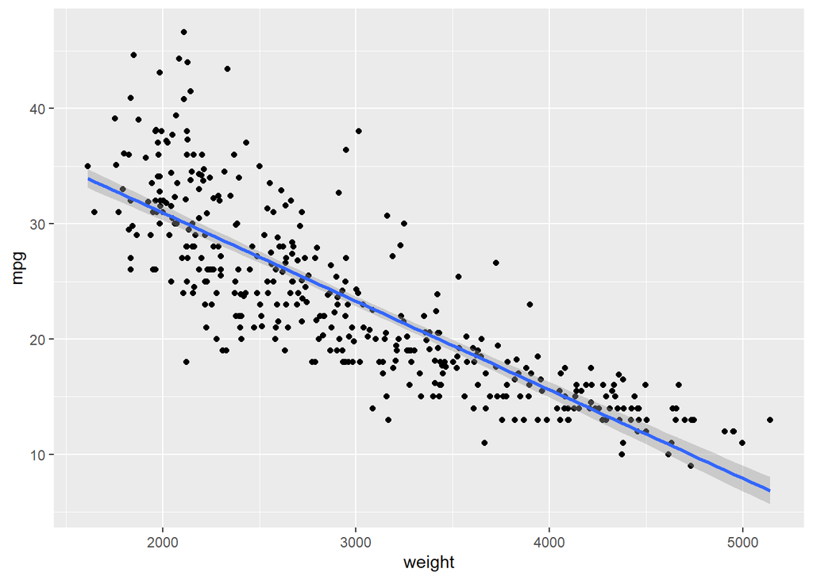

```r
ggplot(data= Autko,aes(weight,mpg)) + geom_point()+ geom_smooth(method=lm)
```

```r
model <- lm(weight~mpg, data= Autko)
summary(model)
```

```
##
## Call:
## lm(formula = weight ~ mpg, data = Autko)
##
## Residuals:
##      Min       1Q   Median       3Q      Max
## -1343.38  -325.09   -25.83   316.90  1349.96
##
## Coefficients:
##             Estimate Std. Error t value Pr(>|t|)
## (Intercept) 5089.487     74.891   67.96   <2e-16 ***
## mpg          -90.117      3.023  -29.81   <2e-16 ***
## ---
## Signif. codes:  0 '***' 0.001 '**' 0.01 '*' 0.05 '.' 0.1 ' ' 1
##
## Residual standard error: 470.7 on 396 degrees of freedom
## Multiple R-squared:  0.6918, Adjusted R-squared:  0.691
## F-statistic: 888.9 on 1 and 396 DF,  p-value: < 2.2e-16
```

- Regresja liniowa mpg i displacement

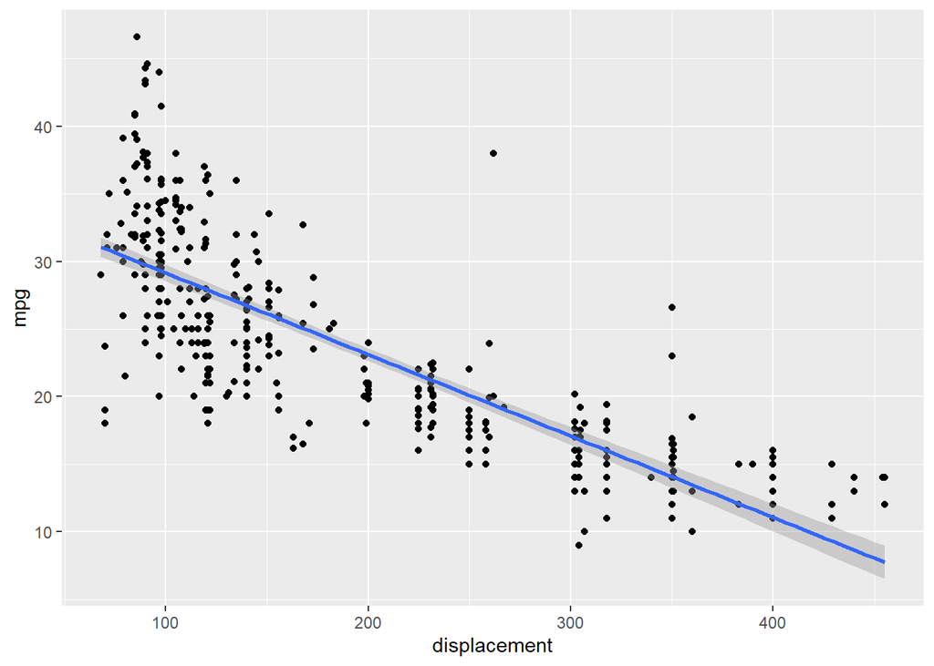

```r
ggplot(Autko,aes(displacement,mpg)) +geom_point()+geom_smooth(method=lm)
```

```r
model <- lm(mpg~displacement, data= Autko)
summary(model)
```

```
##
## Call:
## lm(formula = mpg ~ displacement, data = Autko)
##
## Residuals:
##      Min       1Q   Median       3Q      Max
## -12.9550  -3.0569  -0.4928   2.3277  18.6192
##
## Coefficients:
##               Estimate Std. Error t value Pr(>|t|)
## (Intercept)  35.174750   0.491824   71.52   <2e-16 ***
## displacement -0.060282   0.002239  -26.93   <2e-16 ***
## ---
## Signif. codes:  0 '***' 0.001 '**' 0.01 '*' 0.05 '.' 0.1 ' ' 1
##
## Residual standard error: 4.651 on 396 degrees of freedom
## Multiple R-squared:  0.6467, Adjusted R-squared:  0.6459
## F-statistic:   725 on 1 and 396 DF,  p-value: < 2.2e-16
```

- Regresja liniowa weight i horsepower

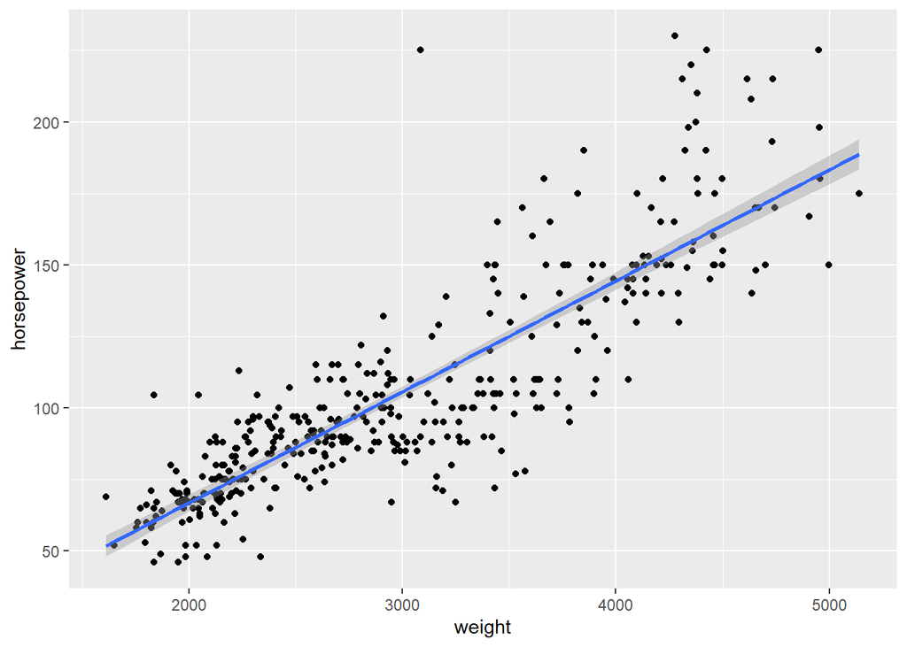

```r
ggplot(Autko,aes(weight, horsepower)) + geom_point() +geom_smooth(method = lm)
```

```r
model <- lm(weight~horsepower, data= Autko)
summary(model)
```

```
##
## Call:
## lm(formula = weight ~ horsepower, data = Autko)
##
## Residuals:
##      Min       1Q   Median       3Q      Max
## -2183.93  -292.08   -81.06   312.01  1157.94
##
## Coefficients:
##             Estimate Std. Error t value Pr(>|t|)
## (Intercept) 977.3408    63.1058   15.49   <2e-16 ***
## horsepower   19.0782     0.5674   33.62   <2e-16 ***
## ---
## Signif. codes:  0 '***' 0.001 '**' 0.01 '*' 0.05 '.' 0.1 ' ' 1
##
## Residual standard error: 431.9 on 396 degrees of freedom
## Multiple R-squared:  0.7406, Adjusted R-squared:  0.7399
## F-statistic:  1131 on 1 and 396 DF,  p-value: < 2.2e-16
```

Budowanie nowych danych do stworzenia korelacji, wybranie tylko kolumn numerycznych

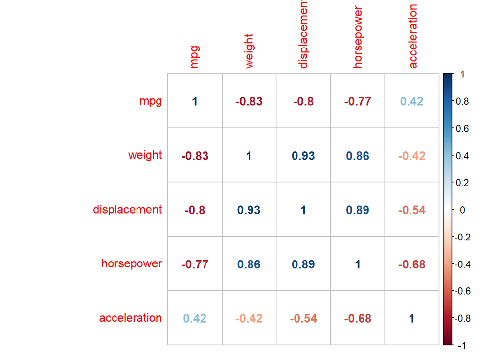

```r
newdata <- cor(Autko[ , c('mpg','weight', 'displacement', 'horsepower', 'acceleration')], use='complete')
corrplot(newdata, method = "number")
```

Wykres korelacji

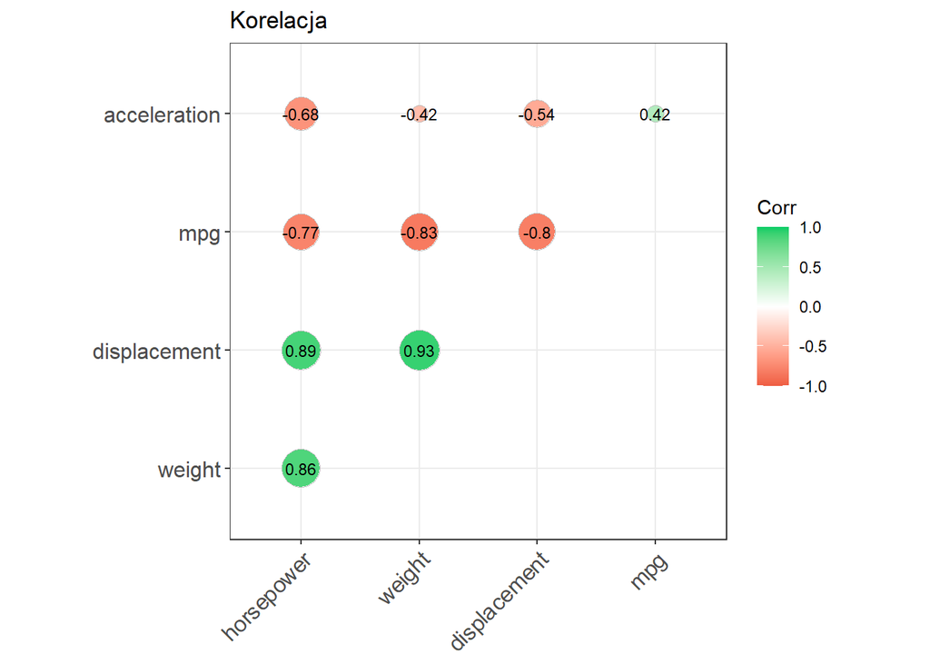

```r
ggcorrplot(newdata, hc.order = TRUE,
           type = "upper",
           lab = TRUE,
           lab_size = 3,
           method="circle",
           colors = c("tomato2", "white", "springgreen3"),
           title="Korelacja",
           ggtheme=theme_bw)
```

Tworzenie regresji liniowej dla całego zbioru z wieloma predyktorami

```r
model <- lm(mpg~weight+horsepower+origin+model_year+displacement+acceleration,data = Autko)
summary(model)
```

```
##
## Call:
## lm(formula = mpg ~ weight + horsepower + origin + model_year +
##     displacement + acceleration, data = Autko)
##
## Residuals:
##    Min     1Q Median     3Q    Max
## -9.213 -1.888 -0.066  1.863 11.683
##
## Coefficients:
##                Estimate Std. Error t value Pr(>|t|)
## (Intercept)  36.4141653  1.9510793  18.664  < 2e-16 ***
## weight       -0.0063635  0.0006284 -10.127  < 2e-16 ***
## horsepower   -0.0214674  0.0127958  -1.678 0.094231 .
## origin2       2.6899477  0.5229265   5.144 4.32e-07 ***
## origin3       2.5356695  0.5104774   4.967 1.03e-06 ***
## model_year71  1.1589904  0.8566572   1.353 0.176887
## model_year72  0.1278785  0.8515633   0.150 0.880711
## model_year73 -0.4560456  0.7700023  -0.592 0.554026
## model_year74  1.7148254  0.8994337   1.907 0.057333 .
## model_year75  1.0814141  0.8888509   1.217 0.224497
## model_year76  1.8391012  0.8533677   2.155 0.031782 *
## model_year77  3.3448755  0.8730736   3.831 0.000149 ***
## model_year78  3.1586630  0.8303347   3.804 0.000166 ***
## model_year79  5.4653256  0.8751153   6.245 1.14e-09 ***
## model_year80  9.5944171  0.9059528  10.590  < 2e-16 ***
## model_year81  7.1203699  0.9054558   7.864 3.92e-14 ***
## model_year82  8.6522401  0.8895808   9.726  < 2e-16 ***
## displacement  0.0157439  0.0054468   2.890 0.004068 **
## acceleration  0.0650602  0.0887770   0.733 0.464103
## ---
## Signif. codes:  0 '***' 0.001 '**' 0.01 '*' 0.05 '.' 0.1 ' ' 1
##
## Residual standard error: 3.052 on 379 degrees of freedom
## Multiple R-squared:  0.8544, Adjusted R-squared:  0.8475
## F-statistic: 123.6 on 18 and 379 DF,  p-value: < 2.2e-16
```

Jak widać acceleration i horsepower są statystycznie nieistotne

Wykresy dla modelu

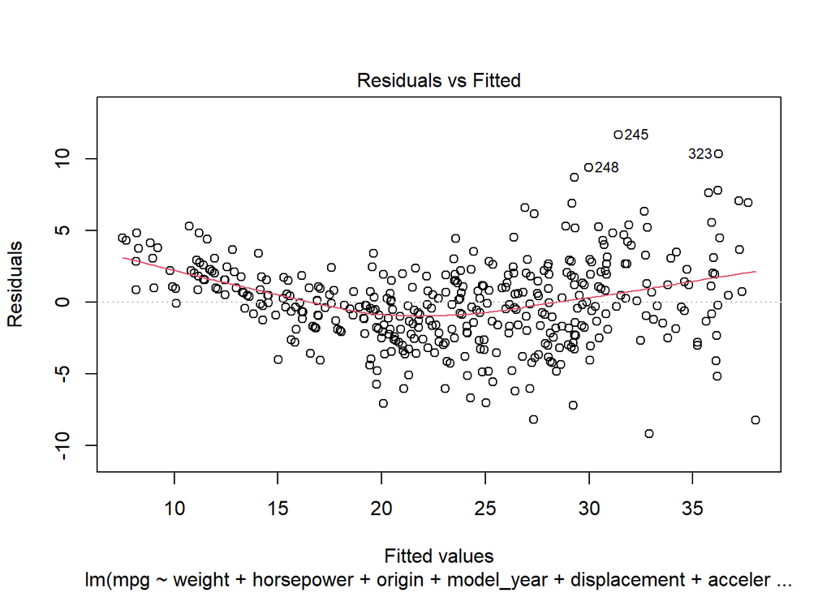

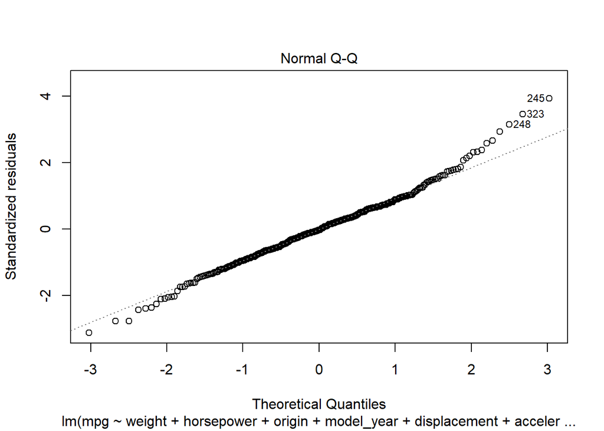

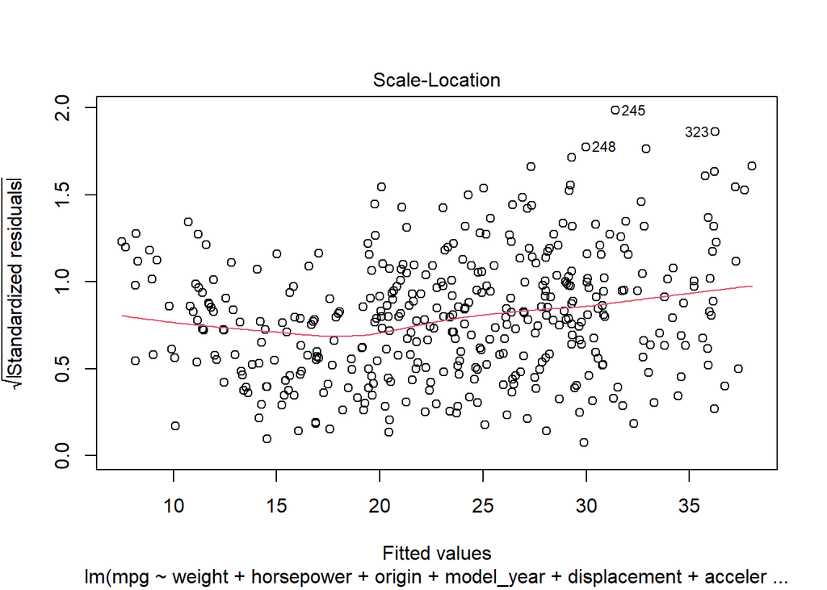

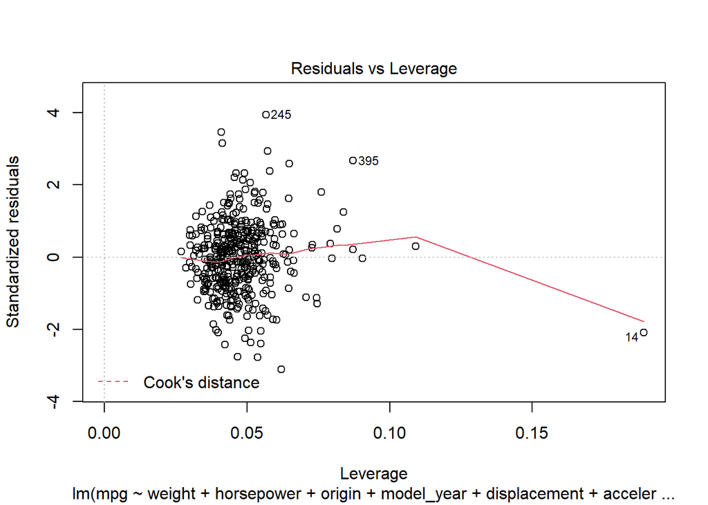

```r
plot(model)
```

Obliczenie błędu RMS

```r
predictions <- predict(model, newdata = testData)
sqrt(mean((predictions - testData$mpg)^2))
```

```
## [1] 2.875063
```

Wykonujemy regresje liniową dla trainingowego zbioru

```r
regresja <- lm( mpg ~ cylinders + displacement + horsepower + weight  + acceleration + origin, data = trainData)
summary(regresja)
```

```
##
## Call:
## lm(formula = mpg ~ cylinders + displacement + horsepower + weight +
##     acceleration + origin, data = trainData)
##
## Residuals:
##     Min      1Q  Median      3Q     Max
## -8.5063 -2.1565 -0.4551  1.7093 16.3808
##
## Coefficients:
##                Estimate Std. Error t value Pr(>|t|)
## (Intercept)  36.6666154  3.6173209  10.136  < 2e-16 ***
## cylinders4    9.8190941  2.1472168   4.573 7.37e-06 ***
## cylinders5   12.6864736  4.7215995   2.687 0.007664 **
## cylinders6    7.0924165  2.5113052   2.824 0.005097 **
## cylinders8    9.5408275  3.0014891   3.179 0.001654 **
## displacement -0.0059951  0.0115048  -0.521 0.602728
## horsepower   -0.0754826  0.0204260  -3.695 0.000266 ***
## weight       -0.0036334  0.0009308  -3.903 0.000120 ***
## acceleration -0.1881372  0.1429827  -1.316 0.189369
## origin2      -0.4362829  0.8260495  -0.528 0.597830
## origin3       3.0172575  0.7669529   3.934 0.000107 ***
## ---
## Signif. codes:  0 '***' 0.001 '**' 0.01 '*' 0.05 '.' 0.1 ' ' 1
##
## Residual standard error: 3.917 on 267 degrees of freedom
## Multiple R-squared:  0.7557, Adjusted R-squared:  0.7466
## F-statistic: 82.61 on 10 and 267 DF,  p-value: < 2.2e-16
```